# Differential gene expression in snow crabs (*Chionoecetes opilio*) in response to different pH treatments

Courtney Skalley

2023-05-09

# 1 Introduction

DOI for github repository May 25, 2023

This project contains a workflow for examining the effect of ocean acidification on gene expression of snow crabs. It runs using paired end RNA-Seq data prepared and provided by Laura Spencer. 63 juvenile crabs were exposed to the following pH treatments:

- control (ambient)
- pH 7.8 (8 hours)
- pH 7.8 (12 weeks)
- pH 7.5 (8 hours)
- pH 7.5 (12 weeks)

On 7/20/2021, after exposure, all crabs were sacrificed by puncturing the carapace through the cardiac region. Crabs were preserved overnight at 4C prior to being transferred to -80C. mRNA samples were then extracted. Each of the 63 mRNA samples were run in both lanes of NovaSeq 6000, for a grand total of 126 paired-end RNA-Seq data sets. Sequence data received January 3, 2022.

[figure not shown]

## 1.1 Links:

- [Rmd file](https://github.com/course-fish546-2023/courtney_RNAseq_crabs/blob/970eec8fea6298725a453ccc06ac890338e26598/code/snowcrabs_dge.Rmd)
- [Output on github](https://github.com/course-fish546-2023/courtney_RNAseq_crabs/tree/main/output)
- DOI for github repository May 25, 2023

## 1.2 Data

The data is located [here](https://drive.google.com/drive/u/1/folders/1w7tqjcd-Rabh0TsWpw-JLTcJ2QbWIh3H), uploaded by LS on 01/12/2022.

Detailed metadata is located [here](https://docs.google.com/document/d/1HzMTreqnY2BD-oyjEJRA-JECpFE4CXlEoWKkmiaTYis/edit#).

# 2 Code

## 2.1 Look at all RNASeq files

There should be 63 samples, each with a forward and reverse sequence (designated by R1 and R2) for a total of 126 files.

```bash
ls /home/shared/8TB_HDD_01/snow_crab/5010
```

## 2.2 Download C. bairdi reference, save it to “data” directory

Here, we use curl to download an available C. bairdi genome and save it to our data directory.

```bash
cd ../data
curl -O https://owl.fish.washington.edu/halfshell/genomic-databank/cbai_genome_v1.0.fasta
```

## 2.3 Set index

We want to index “cbai_genome_v1.0.fasta” and rename it as “cbai_genome_v1.0.index” while also keeping it in the data folder. We can do this by using kallisto.

```bash
/home/shared/kallisto/kallisto \
index -i \
../data/cbai_genome_v1.0.index \
../data/cbai_genome_v1.0.fasta
```

## 2.4 Create abundance estimates

First, we want to make a new directory called “kallisto_paired” in our output folder. We then create a folder within “kallisto_paired” for each crab sample that will each hold the abundance estimates generated by kallisto. The name of each folder will match the basename of the original RNAseq file. This will generate 126 folders (two for each sample–both forward and reverse) so we will later have to remove one folder (will be empty) from each pair.

Then, we tell Kallisto which files we want it to quantify. Kallisto does a psuedo-alignment of each file using an index (“cbai_genome_v1.0.index”), then quantifies the abundance of each contig. We will look for all fastq.gz files in the directory /5010 (our 126 RNA seq files), using wildcard (*) to files with any base name.

We ask kallisto to generate abundance estimates using both forward and reverse reads and bundle them into a file that we already created and named accordingly.

Now, we can remove all folders in our “kallisto_paired” folder that are empty, which will be those ending in “R2_001.fastq.gz”.

```bash
#make a new directory in output
mkdir ../output/kallisto_paired

#find specific files and create abundance estimates
find /home/shared/8TB_HDD_01/snow_crab/5010/*fastq.gz \
| xargs basename -s _L003_R1_001.fastq.gz | xargs -I{} \
/home/shared/kallisto/kallisto \
quant -i ../data/cbai_genome_v1.0.index \
-o ../output/kallisto_paired/{} \
-t 40 \
/home/shared/8TB_HDD_01/snow_crab/5010/{}_L003_R1_001.fastq.gz \
/home/shared/8TB_HDD_01/snow_crab/5010/{}_L003_R2_001.fastq.gz

# delete empty files
rm ../output/kallisto_paired/*R2_001.fastq.gz
```

## 2.5 Create a gene expression matrix from kallisto output files

We first can list all folder names in our kallisto_paired file, then use this list in our next step.

```bash
ls ~/courtney_RNAseq_crabs/output/kallisto_paired
#use these folder names for perl input
```

Now, we use abundance_estimates_to_matrix.pl script from the Trinity RNA-seq assembly software package to create a matrix with all of the abundance.tsv files. This will generate a matrix called “kallisto_paired.isoform.counts.matrix” in our output folder.

```bash
#Sample name input for perl
perl /home/shared/trinityrnaseq-v2.12.0/util/abundance_estimates_to_matrix.pl \
--est_method kallisto \
    --gene_trans_map none \
    --out_prefix ../output/kallisto_paired \
    --name_sample_by_basedir \
    ../output/kallisto_paired/5010_1_S1/abundance.tsv \
    ../output/kallisto_paired/5010_2_S2/abundance.tsv \
    ../output/kallisto_paired/5010_3_S3/abundance.tsv \
    ../output/kallisto_paired/5010_4_S4/abundance.tsv \
    ../output/kallisto_paired/5010_5_S5/abundance.tsv \
    ../output/kallisto_paired/5010_6_S6/abundance.tsv \
    ../output/kallisto_paired/5010_7_S7/abundance.tsv \
    ../output/kallisto_paired/5010_8_S8/abundance.tsv \
    ../output/kallisto_paired/5010_9_S9/abundance.tsv \
    ../output/kallisto_paired/5010_10_S10/abundance.tsv \
    ../output/kallisto_paired/5010_11_S11/abundance.tsv \
    ../output/kallisto_paired/5010_12_S12/abundance.tsv \
    ../output/kallisto_paired/5010_13_S13/abundance.tsv \
    ../output/kallisto_paired/5010_14_S14/abundance.tsv \
    ../output/kallisto_paired/5010_15_S15/abundance.tsv \
    ../output/kallisto_paired/5010_16_S16/abundance.tsv \
    ../output/kallisto_paired/5010_17_S17/abundance.tsv \
    ../output/kallisto_paired/5010_18_S18/abundance.tsv \
    ../output/kallisto_paired/5010_19_S19/abundance.tsv \
    ../output/kallisto_paired/5010_20_S20/abundance.tsv \
    ../output/kallisto_paired/5010_21_S21/abundance.tsv \
    ../output/kallisto_paired/5010_22_S22/abundance.tsv \
    ../output/kallisto_paired/5010_23_S23/abundance.tsv \
    ../output/kallisto_paired/5010_24_S24/abundance.tsv \
    ../output/kallisto_paired/5010_25_S25/abundance.tsv \
    ../output/kallisto_paired/5010_26_S26/abundance.tsv \
    ../output/kallisto_paired/5010_27_S27/abundance.tsv \
    ../output/kallisto_paired/5010_28_S28/abundance.tsv \
    ../output/kallisto_paired/5010_29_S29/abundance.tsv \
    ../output/kallisto_paired/5010_30_S30/abundance.tsv \
    ../output/kallisto_paired/5010_31_S31/abundance.tsv \
    ../output/kallisto_paired/5010_32_S32/abundance.tsv \
    ../output/kallisto_paired/5010_33_S33/abundance.tsv \
    ../output/kallisto_paired/5010_34_S34/abundance.tsv \
    ../output/kallisto_paired/5010_35_S35/abundance.tsv \
    ../output/kallisto_paired/5010_36_S36/abundance.tsv \
    ../output/kallisto_paired/5010_37_S37/abundance.tsv \
    ../output/kallisto_paired/5010_38_S38/abundance.tsv \
    ../output/kallisto_paired/5010_39_S39/abundance.tsv \
    ../output/kallisto_paired/5010_40_S40/abundance.tsv \
    ../output/kallisto_paired/5010_41_S41/abundance.tsv \
    ../output/kallisto_paired/5010_42_S42/abundance.tsv \
    ../output/kallisto_paired/5010_43_S43/abundance.tsv \
    ../output/kallisto_paired/5010_44_S44/abundance.tsv \
    ../output/kallisto_paired/5010_45_S45/abundance.tsv \
    ../output/kallisto_paired/5010_46_S46/abundance.tsv \
    ../output/kallisto_paired/5010_47_S47/abundance.tsv \
    ../output/kallisto_paired/5010_48_S48/abundance.tsv \
    ../output/kallisto_paired/5010_49_S49/abundance.tsv \
    ../output/kallisto_paired/5010_50_S50/abundance.tsv \
    ../output/kallisto_paired/5010_51_S51/abundance.tsv \
    ../output/kallisto_paired/5010_52_S52/abundance.tsv \
    ../output/kallisto_paired/5010_53_S53/abundance.tsv \
    ../output/kallisto_paired/5010_54_S54/abundance.tsv \
    ../output/kallisto_paired/5010_55_S55/abundance.tsv \
    ../output/kallisto_paired/5010_56_S56/abundance.tsv \
    ../output/kallisto_paired/5010_57_S57/abundance.tsv \
    ../output/kallisto_paired/5010_58_S58/abundance.tsv \
    ../output/kallisto_paired/5010_59_S59/abundance.tsv \
    ../output/kallisto_paired/5010_60_S60/abundance.tsv \
    ../output/kallisto_paired/5010_61_S61/abundance.tsv \
    ../output/kallisto_paired/5010_62_S62/abundance.tsv \
    ../output/kallisto_paired/5010_63_S63/abundance.tsv
```

## 2.6 Get packages

Download these packages to generate figures and differntial gene expression.

## 2.7 Read in count matrix

Save our count matrix from its location into a local object in R. Label the rows and columns of the matrix.

```r
countmatrix <- read.delim("../output/kallisto_paired.isoform.counts.matrix", header = TRUE, sep = '\t')
rownames(countmatrix) <- countmatrix$X
countmatrix <- countmatrix[,-1]
head(countmatrix)
```

```
##             X5010_1_S1 X5010_2_S2 X5010_3_S3 X5010_4_S4 X5010_5_S5 X5010_6_S6
## contig_3677  826.95200   84.39420  311.85700    44.0388   73.00000  101.28200
## contig_551    10.78500   10.22240    6.04837     0.0000    8.52952    0.00000
## contig_2354    1.25878    2.45334    0.00000     0.0000    0.00000    1.17853
## contig_1623    1.27709   20.22590    0.00000     0.0000  174.84500    0.00000
## contig_3784  318.48400  276.34100  173.72400   191.0710  260.15200  179.54500
## contig_453     0.00000    0.00000    0.00000     0.0000    2.01666    1.00364
##             X5010_7_S7 X5010_8_S8 X5010_9_S9 X5010_10_S10 X5010_11_S11
## contig_3677  105.12200  170.98900  358.74500     150.1950    136.84000
## contig_551     1.45547    2.74287    7.74467      13.3783     17.61910
## contig_2354    1.15811    1.30359    0.00000       0.0000      3.89947
## contig_1623    0.00000   24.25130    1.67627       5.4100      0.00000
## contig_3784  163.23900  364.76700  542.24400     478.7500    255.99000
## contig_453     0.00000    0.00000    0.00000       0.0000      0.00000
##             X5010_12_S12 X5010_13_S13 X5010_14_S14 X5010_15_S15 X5010_16_S16
## contig_3677     83.05630    584.46000    137.85000     113.1400     93.61910
## contig_551       5.27151      4.26126      2.71456      12.3357      1.61551
## contig_2354      5.12464      2.43988      3.47747       0.0000      7.38579
## contig_1623     13.83930      8.43169      0.00000       0.0000      0.00000
## contig_3784    274.07300    319.06000    465.23300     595.2260    400.90900
## contig_453       0.00000      0.00000      1.03679       0.0000      1.00969
##             X5010_17_S17 X5010_18_S18 X5010_19_S19 X5010_20_S20 X5010_21_S21
## contig_3677    125.35900     66.15110     82.31020      64.0000    108.76500
## contig_551       9.35177     19.44690      3.40289       2.3116      6.61237
## contig_2354      1.13798      4.58402      8.48434       0.0000      3.88187
## contig_1623      6.43131    217.67600      4.40942      24.3209     11.95220
## contig_3784    351.61900    288.11600    210.51400     224.6160    181.11400
## contig_453       0.00000      0.00000      0.00000       0.0000      0.00000
##             X5010_22_S22 X5010_23_S23 X5010_24_S24 X5010_25_S25 X5010_26_S26
## contig_3677    104.25700     60.57210     92.19830     88.12340    112.90400
## contig_551       3.83241      8.09999     19.44950     22.75870      6.34299
## contig_2354      3.95112      5.51476      3.44172      2.98265      6.92777
## contig_1623      4.32650    329.15600      7.19839      1.53834      5.98053
## contig_3784    438.27900    446.79800    390.37000    402.17700    274.57000
## contig_453       0.00000      0.00000      1.01785      0.00000      1.00131
##             X5010_27_S27 X5010_28_S28 X5010_29_S29 X5010_30_S30 X5010_31_S31
## contig_3677    187.58500    173.37500     58.65560     63.05000     86.70020
## contig_551       4.00957      1.34195      3.81138      4.12474      5.61875
## contig_2354      2.38835      1.17504      2.45281      1.30954      0.00000
## contig_1623      6.68866      0.00000      4.35702      3.78490     20.16760
```

[output cut: 36 more lines]

```
## contig_453       0.00000      2.00339      0.00000      0.00000      1.02605
##             X5010_57_S57 X5010_58_S58 X5010_59_S59 X5010_60_S60 X5010_61_S61
## contig_3677     84.15200      129.472    116.00000      57.5758    120.76200
## contig_551       3.14446        0.000      3.81271      15.8914      9.21032
## contig_2354      2.59376        0.000      0.00000       7.2040     10.94710
## contig_1623    297.32700      183.620      6.57290      13.4404      2.64150
## contig_3784    375.88700      561.064    320.28700     425.2500    394.29200
## contig_453       2.08115        0.000      0.00000       0.0000      0.00000
##             X5010_62_S62 X5010_63_S63
## contig_3677     97.69350    128.18400
## contig_551      23.82790      2.46923
## contig_2354      2.34724      1.11446
## contig_1623      2.75472      0.00000
## contig_3784    354.43700    366.75000
## contig_453       0.00000      0.00000
```

### 2.7.1 Round up to whole numbers

```
## 'data.frame':    3294 obs. of  63 variables:
##  $ X5010_1_S1  : num  827 11 1 1 318 ...
##  $ X5010_2_S2  : num  84 10 2 20 276 ...
##  $ X5010_3_S3  : num  312 6 0 0 174 ...
##  $ X5010_4_S4  : num  44 0 0 0 191 0 27 141 878 2160 ...
##  $ X5010_5_S5  : num  73 9 0 175 260 ...
##  $ X5010_6_S6  : num  101 0 1 0 180 ...
##  $ X5010_7_S7  : num  105 1 1 0 163 ...
##  $ X5010_8_S8  : num  171 3 1 24 365 ...
##  $ X5010_9_S9  : num  359 8 0 2 542 ...
##  $ X5010_10_S10: num  150 13 0 5 479 ...
##  $ X5010_11_S11: num  137 18 4 0 256 ...
##  $ X5010_12_S12: num  83 5 5 14 274 ...
##  $ X5010_13_S13: num  584 4 2 8 319 ...
##  $ X5010_14_S14: num  138 3 3 0 465 ...
```

[output cut: 49 more lines]

## 2.8 Get differential gene expression based on pH exposure

Use DESeq2 to make a differential gene expression. Looking at metadata, we can see that the first 12 samples were the “control”, followed by 14 “pH 7.5-long exposure”, 12 “pH 7.5-short exposure”, 14 “pH 7.8-long exposure”, then 11 “pH 7.8-short exposure”. This gives us a total of 63 “paired-end” reads. This information can be used to label the matrix accordingly.

```
## [1] 3294   63
```

```
## [1] 63  2
```

```
##                condition       type
## 1                control paired-end
## 2                control paired-end
## 3                control paired-end
## 4                control paired-end
## 5                control paired-end
## 6                control paired-end
## 7                control paired-end
## 8                control paired-end
## 9                control paired-end
## 10               control paired-end
## 11               control paired-end
## 12               control paired-end
## 13  pH 7.5-long exposure paired-end
## 14  pH 7.5-long exposure paired-end
```

[output cut: 49 more lines]

```
## class: DESeqDataSet
## dim: 3294 63
## metadata(1): version
## assays(1): counts
## rownames(3294): contig_3677 contig_551 ... contig_4738 contig_3758
## rowData names(0):
## colnames(63): X5010_1_S1 X5010_2_S2 ... X5010_62_S62 X5010_63_S63
## colData names(2): condition type
```

Here, we save the results to local object “deseq2.dds” so that we can create plots in R.

## 2.9 Look at DESeq matrix

Look at deseq2.res to make sure that nothing looks off. Should a dataFrame with 6 rows and 6 columns.

```r
head(deseq2.res)
```

```
## log2 fold change (MLE): condition pH.7.8.short.exposure vs control
## Wald test p-value: condition pH.7.8.short.exposure vs control
## DataFrame with 6 rows and 6 columns
##              baseMean log2FoldChange     lfcSE      stat    pvalue      padj
##             <numeric>      <numeric> <numeric> <numeric> <numeric> <numeric>
## contig_100   37.11779       0.378808  0.398122  0.951487  0.341357  0.768479
## contig_1000  41.73616       0.271854  0.181810  1.495270  0.134844  0.583872
## contig_1003  54.68653       0.184489  0.409173  0.450882  0.652075  0.912112
## contig_1005   7.97371       0.165513  0.371475  0.445555  0.655919  0.913866
## contig_1006  72.35878      -0.308162  0.562138 -0.548196  0.583557  0.888517
## contig_1007 674.88257      -0.160801  0.182866 -0.879335  0.379220  0.797610
```

## 2.10 Look for signficant values

Count the number of hits with adjusted p-value less then 0.05

```r
dim(deseq2.res[!is.na(deseq2.res$padj) & deseq2.res$padj <= 0.05, ])
```

```
## [1] 25  6
```

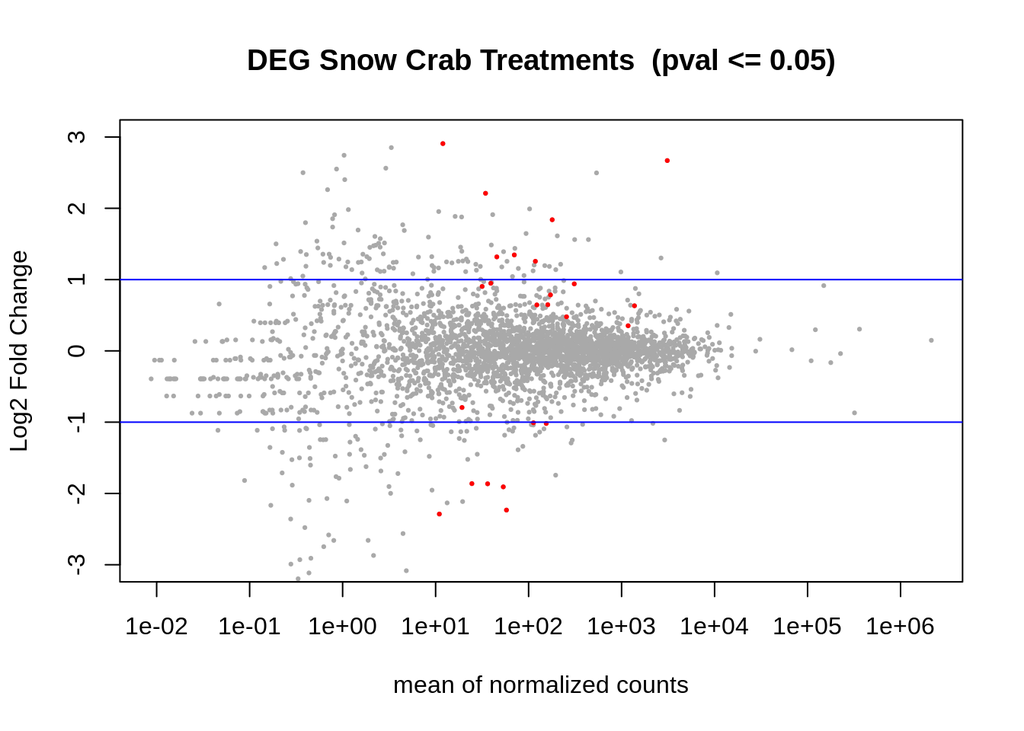

```r
tmp <- deseq2.res
# The main plot
plot(tmp$baseMean, tmp$log2FoldChange, pch=20, cex=0.45, ylim=c(-3, 3), log="x", col="darkgray",
     main="DEG Snow Crab Treatments  (pval <= 0.05)",
     xlab="mean of normalized counts",
     ylab="Log2 Fold Change")
# Getting the significant points and plotting them again so they're a different color
tmp.sig <- deseq2.res[!is.na(deseq2.res$padj) & deseq2.res$padj <= 0.05, ]
points(tmp.sig$baseMean, tmp.sig$log2FoldChange, pch=20, cex=0.45, col="red")
# 2 FC lines
abline(h=c(-1,1), col="blue")
```

```r
write.table(tmp.sig, "../output/DEGlist.tab", row.names = T)
```